# Path analysis: NCP → Biogeochemistry → Coral physiology

# Tank-level path analysis

## Data preparation

Tank-level means are used as the unit of analysis (n = 16 independent tanks), avoiding within-tank pseudoreplication. All continuous variables are z-scored for standardized path coefficients.

**Note**

All chemistry variables (NCP, pH, DOC) are computed from **daytime (12:00) measurements only** using the seacarb carbonate chemistry pipeline, and the same outlier filters applied throughout the analysis. An alternative pre-computed summary file (`Raw_Chem_Data.csv`) exists that averages both day and night time points without outlier filtering; the two sources yield pH values that differ by up to 0.09 units (r = 0.76) and DOC values that correlate at only r = 0.44. The daytime-only pipeline values are used here to maintain consistency with how NCP is measured (daytime flux) and how the physiological measurements were interpreted.

```r
# Tank-level daytime means for NCP, pH, DOC — consistent with NCP measurement timing
tank_chem <- chem_reframe_DAY_clean |>
  group_by(TREATMENT, TANK_NUM) |>
  summarize(
    NEP_mean = mean(NEP,       na.rm = TRUE),
    pH_mean  = mean(pH,        na.rm = TRUE),
    DOC_mean = log(mean(DOC,   na.rm = TRUE)),
    .groups  = "drop"
  ) |>
  drop_na() |>
  mutate(TREATMENT = factor(TREATMENT, levels = treatment_levels))

# Tank-level physiology means
tank_physio <- metadata |>
 # mutate (GP = ifelse(GP > 6, NA, GP)
#  ) |>
  group_by(TANK_NUM, TREATMENT) |>
  summarize(
    mean_chla    = mean(chla_ug_cm2,        na.rm = TRUE),
    mean_endo    = mean(endo_per_cm2,        na.rm = TRUE),
    mean_biomass = mean(mean_tissue_biomass, na.rm = TRUE),
    mean_GP      = mean(GP,                 na.rm = TRUE),
    mean_R       = mean(R,                  na.rm = TRUE),
    .groups      = "drop"
  ) |>
  mutate(TREATMENT = factor(TREATMENT, levels = treatment_levels))

tank_full <- tank_physio |>
  mutate(
    log_chla    = log(mean_chla),
    log_endo    = log(mean_endo),
    log_biomass = log(mean_biomass)
  )

# Join chemistry and physiology; z-score all continuous variables
tank_path_data <- tank_chem |>
  mutate(TANK_NUM = as.numeric(TANK_NUM)) |>
  left_join(
    tank_full |> select(TANK_NUM, log_chla, log_endo, log_biomass, mean_GP, mean_R),
    by = "TANK_NUM"
  ) |>
  mutate(across(c(NEP_mean, pH_mean, DOC_mean,
                  log_chla, log_endo, log_biomass, mean_GP, mean_R), scale)) |>
  drop_na()

cat("n tanks in path model:", nrow(tank_path_data), "\n")
```

```
n tanks in path model: 16
```

```r
cat("pH range (pipeline daytime):", round(diff(range(tank_chem$pH_mean, na.rm = TRUE)), 4), "units\n")
```

```
pH range (pipeline daytime): 0.1229 units
```

```r
cat("DOC range (pipeline daytime):", round(diff(range(tank_chem$DOC_mean, na.rm = TRUE)), 3), "log-µmol/L\n")
```

```
DOC range (pipeline daytime): 0.519 log-µmol/L
```

## Path model

Path coefficients are labeled (c, d, e, f) to enable indirect effect computation via the delta method.

```r
tank_path_model <- "
  # NCP → pH (c1) and DOC (d1)
  pH_mean  ~ c1*NEP_mean
  DOC_mean ~ d1*NEP_mean

  # pH (e1) and DOC (e2) → Chl-a
  log_chla ~ e1*pH_mean + e2*DOC_mean

  # Chl-a → downstream physiology (f1–f4)
  log_endo    ~ f1*log_chla
  mean_GP     ~ f2*log_chla
  mean_R      ~ f3*log_chla
  log_biomass ~ f4*log_chla

  # Residual covariance between pH and DOC after accounting for NCP
  pH_mean ~~ DOC_mean

  # --- Indirect effects ---

  # NCP → pH/DOC → Chl-a (two-step)
  ind_NCP_pH_Chla     := c1 * e1
  ind_NCP_DOC_Chla    := d1 * e2
  ind_NCP_total_Chla  := (c1 * e1) + (d1 * e2)

  # pH → Chl-a → downstream (two-step)
  ind_pH_Chla_Endo    := e1 * f1
  ind_pH_Chla_GP      := e1 * f2
  ind_pH_Chla_R       := e1 * f3
  ind_pH_Chla_Biomass := e1 * f4

  # DOC → Chl-a → downstream (two-step)
  ind_DOC_Chla_Endo    := e2 * f1
  ind_DOC_Chla_GP      := e2 * f2
  ind_DOC_Chla_R       := e2 * f3
  ind_DOC_Chla_Biomass := e2 * f4

  # NCP → pH → Chl-a → downstream (three-step via pH)
  ind_NCP_pH_Endo     := c1 * e1 * f1
  ind_NCP_pH_GP       := c1 * e1 * f2
  ind_NCP_pH_R        := c1 * e1 * f3
  ind_NCP_pH_Biomass  := c1 * e1 * f4

  # NCP → DOC → Chl-a → downstream (three-step via DOC)
  ind_NCP_DOC_Endo    := d1 * e2 * f1
  ind_NCP_DOC_GP      := d1 * e2 * f2
  ind_NCP_DOC_R       := d1 * e2 * f3
  ind_NCP_DOC_Biomass := d1 * e2 * f4
"

tank_path_fit <- sem(
  tank_path_model,
  data      = as.data.frame(tank_path_data),
  estimator = "ML"
)
cat("Converged:", lavInspect(tank_path_fit, "converged"), "\n")
```

```
Converged: TRUE
```

## Direct path coefficients

```r
tank_path_coefs <- parameterEstimates(tank_path_fit, standardized = TRUE) |>
  filter(op == "~") |>
  select(lhs, rhs, est, se, z, pvalue, std.all) |>
  mutate(
    lhs = recode(lhs,
      NEP_mean    = "NCP",
      pH_mean     = "pH",
      DOC_mean    = "DOC (log)",
      log_chla    = "Chl-a (log)",
      log_endo    = "Endosymbiont (log)",
      mean_GP     = "Gross photosynthesis",
      mean_R      = "Respiration",
      log_biomass = "Tissue biomass (log)"
    ),
    rhs = recode(rhs,
      NEP_mean = "NCP",
      pH_mean  = "pH",
      DOC_mean = "DOC (log)",
      log_chla = "Chl-a (log)"
    ),
    across(where(is.numeric), ~ round(.x, 4))
  )

tank_path_coefs |>
  kbl(
    caption = paste0(
      "Direct path coefficients from the tank-level SEM (n = ",
      nrow(tank_path_data), " tanks). All variables z-scored. ",
      "Green = p < 0.05; yellow = 0.05 ≤ p < 0.10."
    ),
    col.names = c("Response", "Predictor", "Estimate", "SE", "z", "p", "Std. β")
  ) |>
  kable_styling(bootstrap_options = c("striped", "condensed"), full_width = FALSE) |>
  row_spec(which(tank_path_coefs$pvalue < 0.05),  background = "#d4edda") |>
  row_spec(which(tank_path_coefs$pvalue >= 0.05 & tank_path_coefs$pvalue < 0.10),
           background = "#fff3cd")
```

Direct path coefficients from the tank-level SEM (n = 16 tanks). All variables z-scored. Green = p < 0.05; yellow = 0.05 ≤ p < 0.10.

| Response | Predictor | Estimate | SE | z | p | Std. β |
| --- | --- | --- | --- | --- | --- | --- |
| pH | NCP | 0.6507 | 0.1898 | 3.4279 | 0.0006 | 0.6507 |
| DOC (log) | NCP | 0.1652 | 0.2466 | 0.6698 | 0.5030 | 0.1652 |
| Chl-a (log) | pH | 0.5418 | 0.2392 | 2.2653 | 0.0235 | 0.5418 |
| Chl-a (log) | DOC (log) | -0.2454 | 0.2392 | -1.0261 | 0.3049 | -0.2454 |
| Endosymbiont (log) | Chl-a (log) | 0.5217 | 0.2133 | 2.4461 | 0.0144 | 0.5217 |
| Gross photosynthesis | Chl-a (log) | 0.2629 | 0.2412 | 1.0899 | 0.2758 | 0.2629 |
| Respiration | Chl-a (log) | 0.6420 | 0.1917 | 3.3493 | 0.0008 | 0.6420 |
| Tissue biomass (log) | Chl-a (log) | 0.5103 | 0.2150 | 2.3734 | 0.0176 | 0.5103 |

## R² for endogenous variables

```r
lavInspect(tank_path_fit, "r2") |>
  tibble::enframe(name = "Variable", value = "R2") |>
  mutate(
    Variable = recode(Variable,
      pH_mean     = "pH",
      DOC_mean    = "DOC (log)",
      log_chla    = "Chl-a (log)",
      log_endo    = "Endosymbiont (log)",
      mean_GP     = "Gross photosynthesis",
      mean_R      = "Respiration",
      log_biomass = "Tissue biomass (log)"
    ),
    R2 = round(R2, 3)
  ) |>
  kbl(
    caption = "R² for each endogenous variable in the daytime-means path model. Values represent the proportion of variance explained by all predictors in the model for each response variable.",
    col.names = c("Variable", "R²")
  ) |>
  kable_styling(bootstrap_options = c("striped", "condensed"), full_width = FALSE, position = "left")
```

R² for each endogenous variable in the daytime-means path model. Values represent the proportion of variance explained by all predictors in the model for each response variable.

| Variable | R² |
| --- | --- |
| pH | 0.423 |
| DOC (log) | 0.027 |
| Chl-a (log) | 0.243 |
| Endosymbiont (log) | 0.272 |
| Gross photosynthesis | 0.069 |
| Respiration | 0.412 |
| Tissue biomass (log) | 0.260 |

## Path diagram

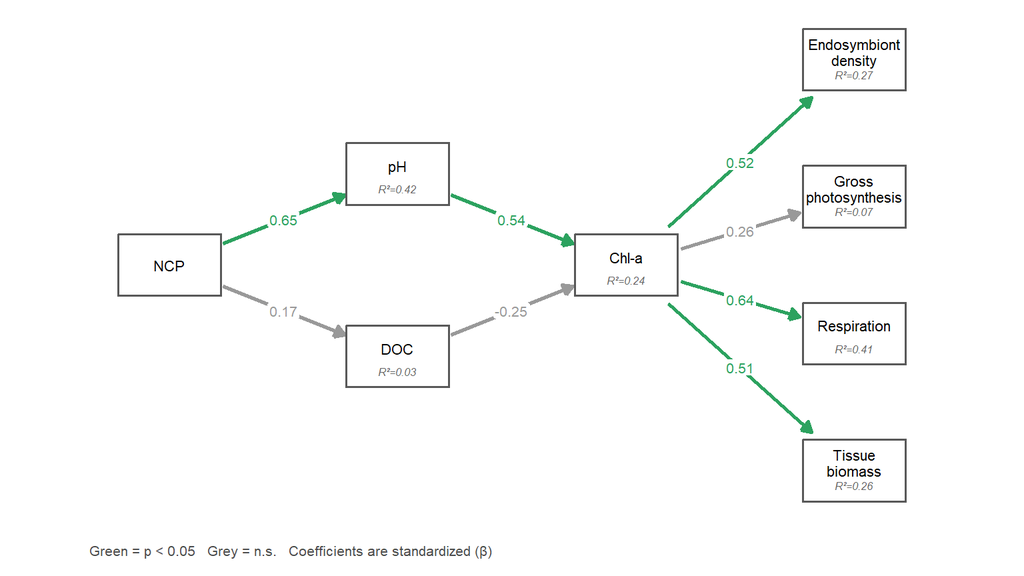

Path diagram summarizing direct paths in the tank-level SEM (means model). Green = p < 0.05; grey = n.s. Numbers are standardized path coefficients (β). n = 16 tanks.

```r
library(purrr)

# Node positions
path_nodes <- tibble(
  id    = c("NCP",  "pH",  "DOC",  "Chla",  "Endo",                 "GP",                   "R",           "Bio"),
  label = c("NCP",  "pH",  "DOC",  "Chl-a", "Endosymbiont\ndensity","Gross\nphotosynthesis", "Respiration", "Tissue\nbiomass"),
  x     = c(1,      3,     3,      5,        7,                       7,                       7,             7),
  y     = c(0,      0.8,  -0.8,    0,        1.8,                     0.6,                    -0.6,          -1.8)
)

# Add R² from model to each endogenous node
r2_m1 <- lavInspect(tank_path_fit, "r2")
path_nodes <- path_nodes |>
  left_join(
    tibble(id = c("pH",     "DOC",      "Chla",     "Endo",     "GP",       "R",      "Bio"),
           r2 = r2_m1[c("pH_mean","DOC_mean","log_chla","log_endo","mean_GP","mean_R","log_biomass")]),
    by = "id"
  ) |>
  mutate(
    r2_label = ifelse(!is.na(r2), sprintf("R\u00b2=%.2f", r2), NA_character_),
    label_y  = ifelse(!is.na(r2), y + 0.07, y)
  )

# Direct path results pulled dynamically from model
path_direct <- parameterEstimates(tank_path_fit, standardized = TRUE) |>
  filter(op == "~") |>
  select(lhs, rhs, std.all, pvalue) |>
  mutate(
    lhs = recode(lhs, NEP_mean="NCP", pH_mean="pH", DOC_mean="DOC",
                 log_chla="Chla", log_endo="Endo", mean_GP="GP", mean_R="R", log_biomass="Bio"),
    rhs = recode(rhs, NEP_mean="NCP", pH_mean="pH", DOC_mean="DOC", log_chla="Chla"),
    sig = pvalue < 0.05
  )

path_edges <- tibble(
  from = c("NCP", "NCP", "pH",   "DOC",  "Chla", "Chla", "Chla", "Chla"),
  to   = c("pH",  "DOC", "Chla", "Chla", "Endo", "GP",   "R",    "Bio")
) |>
  left_join(path_direct |> select(lhs, rhs, std.all, sig),
            by = c("to" = "lhs", "from" = "rhs")) |>
  left_join(path_nodes |> select(id, x, y), by = c("from" = "id")) |>
  rename(x0 = x, y0 = y) |>
  left_join(path_nodes |> select(id, x, y), by = c("to" = "id")) |>
  rename(x1 = x, y1 = y)

shorten_arrow <- function(x0, y0, x1, y1, d_start = 0.5, d_end = 0.5) {
  dx <- x1 - x0; dy <- y1 - y0; d <- sqrt(dx^2 + dy^2)
  tibble(xs = x0 + dx/d*d_start, ys = y0 + dy/d*d_start,
         xe = x1 - dx/d*d_end,   ye = y1 - dy/d*d_end,
         mx = (x0 + dx/d*d_start + x1 - dx/d*d_end) / 2,
         my = (y0 + dy/d*d_start + y1 - dy/d*d_end) / 2)
}

edge_coords <- pmap_dfr(path_edges, function(from, to, std.all, sig, x0, y0, x1, y1) {
  pts <- shorten_arrow(x0, y0, x1, y1)
  tibble(from, to, coef = std.all, sig,
         xs = pts$xs, ys = pts$ys, xe = pts$xe, ye = pts$ye,
         mx = pts$mx, my = pts$my)
})

ggplot() +
  geom_segment(
    data = edge_coords,
    aes(x = xs, y = ys, xend = xe, yend = ye, color = sig),
    linewidth = 0.9,
    arrow = arrow(length = unit(0.22, "cm"), type = "closed"),
    show.legend = FALSE
  ) +
  geom_label(
    data = edge_coords,
    aes(x = mx, y = my, label = sprintf("%.2f", coef), color = sig),
    size = 2.8, label.padding = unit(0.12, "lines"), label.size = 0,
    fill = "white", show.legend = FALSE
  ) +
  geom_tile(
    data = path_nodes,
    aes(x = x, y = y),
    width = 0.9, height = 0.54,
    fill = "white", color = "grey35", linewidth = 0.6
  ) +
  geom_text(
    data = path_nodes,
    aes(x = x, y = label_y, label = label),
    size = 2.9, lineheight = 0.9
  ) +
  geom_text(
    data = path_nodes |> filter(!is.na(r2_label)),
    aes(x = x, y = y - 0.13, label = r2_label),
    size = 2.1, color = "grey40", fontface = "italic"
  ) +
  scale_color_manual(values = c("TRUE" = "#2ca25f", "FALSE" = "grey60")) +
  annotate("text", x = 0.3, y = -2.5,
           label = "Green = p < 0.05   Grey = n.s.   Coefficients are standardized (\u03b2)",
           hjust = 0, size = 2.8, color = "grey30") +
  coord_equal(xlim = c(0.3, 7.7), ylim = c(-2.6, 2.2), expand = FALSE) +
  theme_void() +
  theme(plot.margin = margin(8, 8, 8, 8))
```

## Indirect effects

```r
indirect_raw <- parameterEstimates(tank_path_fit, standardized = TRUE) |>
  filter(op == ":=") |>
  select(label, est, se, z, pvalue, std.all) |>
  mutate(
    Pathway = recode(label,
      ind_NCP_pH_Chla      = "NCP → pH → Chl-a",
      ind_NCP_DOC_Chla     = "NCP → DOC → Chl-a",
      ind_NCP_total_Chla   = "NCP → [pH + DOC] → Chl-a  (total)",
      ind_pH_Chla_Endo     = "pH → Chl-a → Endosymbiont",
      ind_pH_Chla_GP       = "pH → Chl-a → Gross photosynthesis",
      ind_pH_Chla_R        = "pH → Chl-a → Respiration",
      ind_pH_Chla_Biomass  = "pH → Chl-a → Tissue biomass",
      ind_DOC_Chla_Endo    = "DOC → Chl-a → Endosymbiont",
      ind_DOC_Chla_GP      = "DOC → Chl-a → Gross photosynthesis",
      ind_DOC_Chla_R       = "DOC → Chl-a → Respiration",
      ind_DOC_Chla_Biomass = "DOC → Chl-a → Tissue biomass",
      ind_NCP_pH_Endo      = "NCP → pH → Chl-a → Endosymbiont",
      ind_NCP_pH_GP        = "NCP → pH → Chl-a → Gross photosynthesis",
      ind_NCP_pH_R         = "NCP → pH → Chl-a → Respiration",
      ind_NCP_pH_Biomass   = "NCP → pH → Chl-a → Tissue biomass",
      ind_NCP_DOC_Endo     = "NCP → DOC → Chl-a → Endosymbiont",
      ind_NCP_DOC_GP       = "NCP → DOC → Chl-a → Gross photosynthesis",
      ind_NCP_DOC_R        = "NCP → DOC → Chl-a → Respiration",
      ind_NCP_DOC_Biomass  = "NCP → DOC → Chl-a → Tissue biomass"
    ),
    across(where(is.numeric), ~ round(.x, 4)),
    Chain = case_when(
      grepl("^NCP → \\[", Pathway) ~ "NCP → Chl-a (total)",
      grepl("^NCP → pH → Chl-a$", Pathway) ~ "NCP → Chl-a (total)",
      grepl("^NCP → DOC → Chl-a$", Pathway) ~ "NCP → Chl-a (total)",
      grepl("^NCP → pH → Chl-a →", Pathway) ~ "NCP → pH → Chl-a → downstream",
      grepl("^NCP → DOC → Chl-a →", Pathway) ~ "NCP → DOC → Chl-a → downstream",
      grepl("^pH", Pathway) ~ "pH → Chl-a → downstream",
      grepl("^DOC", Pathway) ~ "DOC → Chl-a → downstream",
      TRUE ~ "Other"
    )
  ) |>
  arrange(Chain, desc(abs(est)))

indirect_raw |>
  select(Chain, Pathway, est, se, z, pvalue, std.all) |>
  kbl(
    caption = paste0(
      "Indirect (mediated) effects from the tank-level SEM. ",
      "Estimates are products of the relevant direct path coefficients; ",
      "SEs are from the delta method. ",
      "Green = p < 0.05; yellow = 0.05 ≤ p < 0.10."
    ),
    col.names = c("Chain group", "Pathway", "Estimate", "SE", "z", "p", "Std. β")
  ) |>
  kable_styling(bootstrap_options = c("striped", "condensed"), full_width = FALSE) |>
  collapse_rows(columns = 1, valign = "top") |>
  row_spec(which(indirect_raw$pvalue < 0.05),  background = "#d4edda") |>
  row_spec(which(indirect_raw$pvalue >= 0.05 & indirect_raw$pvalue < 0.10),
           background = "#fff3cd")
```

Indirect (mediated) effects from the tank-level SEM. Estimates are products of the relevant direct path coefficients; SEs are from the delta method. Green = p < 0.05; yellow = 0.05 ≤ p < 0.10.

| Chain group | Pathway | Estimate | SE | z | p | Std. β |
| --- | --- | --- | --- | --- | --- | --- |
| DOC → Chl-a → downstream | DOC → Chl-a → Respiration | -0.1576 | 0.1606 | -0.9810 | 0.3266 | -0.1576 |
|  | DOC → Chl-a → Endosymbiont | -0.1280 | 0.1353 | -0.9462 | 0.3441 | -0.1280 |
|  | DOC → Chl-a → Tissue biomass | -0.1252 | 0.1330 | -0.9418 | 0.3463 | -0.1252 |
|  | DOC → Chl-a → Gross photosynthesis | -0.0645 | 0.0864 | -0.7471 | 0.4550 | -0.0645 |
| NCP → Chl-a (total) | NCP → pH → Chl-a | 0.3526 | 0.1866 | 1.8899 | 0.0588 | 0.3526 |
|  | NCP → [pH + DOC] → Chl-a (total) | 0.3120 | 0.1726 | 1.8082 | 0.0706 | 0.3120 |
|  | NCP → DOC → Chl-a | -0.0405 | 0.0723 | -0.5609 | 0.5749 | -0.0405 |
| NCP → DOC → Chl-a → downstream | NCP → DOC → Chl-a → Respiration | -0.0260 | 0.0470 | -0.5532 | 0.5801 | -0.0260 |
|  | NCP → DOC → Chl-a → Endosymbiont | -0.0211 | 0.0387 | -0.5467 | 0.5846 | -0.0211 |
|  | NCP → DOC → Chl-a → Tissue biomass | -0.0207 | 0.0379 | -0.5459 | 0.5852 | -0.0207 |
|  | NCP → DOC → Chl-a → Gross photosynthesis | -0.0107 | 0.0214 | -0.4987 | 0.6180 | -0.0107 |
| NCP → pH → Chl-a → downstream | NCP → pH → Chl-a → Respiration | 0.2263 | 0.1375 | 1.6459 | 0.0998 | 0.2263 |
|  | NCP → pH → Chl-a → Endosymbiont | 0.1839 | 0.1230 | 1.4955 | 0.1348 | 0.1839 |
|  | NCP → pH → Chl-a → Tissue biomass | 0.1799 | 0.1217 | 1.4784 | 0.1393 | 0.1799 |
|  | NCP → pH → Chl-a → Gross photosynthesis | 0.0927 | 0.0982 | 0.9441 | 0.3451 | 0.0927 |
| pH → Chl-a → downstream | pH → Chl-a → Respiration | 0.3478 | 0.1854 | 1.8764 | 0.0606 | 0.3478 |
|  | pH → Chl-a → Endosymbiont | 0.2827 | 0.1701 | 1.6620 | 0.0965 | 0.2827 |
|  | pH → Chl-a → Tissue biomass | 0.2765 | 0.1687 | 1.6387 | 0.1013 | 0.2765 |
|  | pH → Chl-a → Gross photosynthesis | 0.1424 | 0.1450 | 0.9821 | 0.3260 | 0.1424 |

## Data visualization

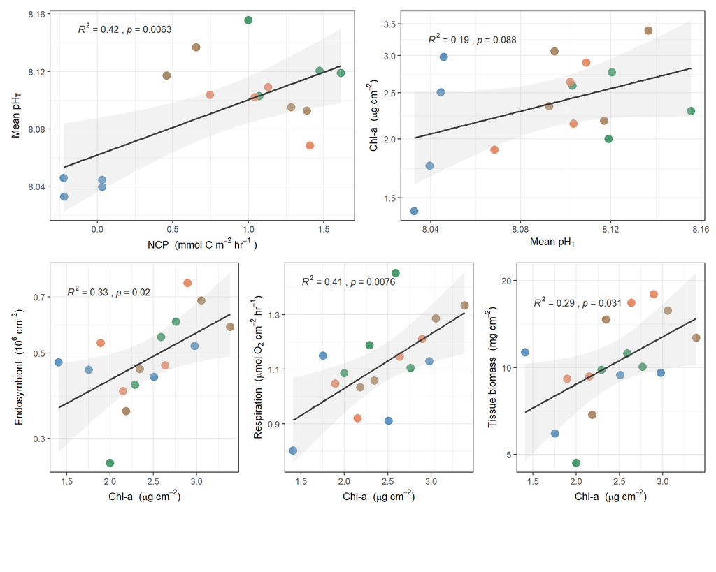

Figure 3: Bivariate relationships for the significant paths in Model 1 (means). Points are tank-level means (n = 16) colored by community treatment. Regression line and R²/p-value are pooled across treatments. Note: bivariate R² will generally be smaller than path model partial coefficients because it does not condition on other variables in the model.

```r
library(ggpubr)
library(patchwork)
library(cowplot)

treat_colors <- c("Control" = "#4682B4", "Algae_Dom" = "#2E8B57",
                  "Coral_Dom" = "#E07B54", "Rubble_Dom" = "#A07850")
treat_labels <- c("Control" = "Control", "Algae_Dom" = "Macroalgae",
                  "Coral_Dom" = "Coral",  "Rubble_Dom" = "CCA")

scatter_path <- function(df, x, y, xlab, ylab, log_y = FALSE) {
  p <- ggplot(df, aes(x = .data[[x]], y = .data[[y]],
                      color = TREATMENT, fill = TREATMENT)) +
    geom_point(size = 3.5, alpha = 0.85) +
    geom_smooth(method = "lm", aes(group = 1),
                color = "grey25", fill = "grey80", se = TRUE,
                linewidth = 0.8, alpha = 0.25) +
    stat_cor(aes(group = 1,
                 label = paste(after_stat(rr.label), after_stat(p.label),
                               sep = "~`,`~")),
             color = "grey20", label.x.npc = 0.05, label.y.npc = 0.97, size = 3.4) +
    scale_color_manual(values = treat_colors, labels = treat_labels, name = NULL) +
    scale_fill_manual(values  = treat_colors, labels = treat_labels, name = NULL) +
    labs(x = xlab, y = ylab) +
    theme_bw(base_size = 11) +
    theme(legend.position = "none", axis.title = element_text(size = 10))
  if (log_y) p <- p + scale_y_log10()
  p
}

# Build plot dataset from pipeline
plot_m1 <- chem_reframe_DAY_clean |>
  group_by(TREATMENT, TANK_NUM) |>
  summarize(NEP_mean = mean(NEP, na.rm = TRUE),
            pH_mean  = mean(pH,  na.rm = TRUE),
            DOC_mean = log(mean(DOC, na.rm = TRUE)),
            .groups  = "drop") |>
  drop_na() |>
  mutate(TANK_NUM  = as.numeric(TANK_NUM),
         TREATMENT = factor(TREATMENT, levels = treatment_levels)) |>
  left_join(tank_full |> select(TANK_NUM, mean_chla, mean_endo, mean_biomass, mean_GP, mean_R),
            by = "TANK_NUM")

p1a <- scatter_path(plot_m1, "NEP_mean", "pH_mean",
                    expression("NCP  (mmol C m"^-2~hr^-1~")"),
                    expression("Mean pH"[T]))
p1b <- scatter_path(plot_m1, "pH_mean", "mean_chla",
                    expression("Mean pH"[T]),
                    expression("Chl-a  ("*mu*g~cm^-2*")"), log_y = TRUE)
p1c <- scatter_path(plot_m1, "mean_chla", "mean_endo",
                    expression("Chl-a  ("*mu*g~cm^-2*")"),
                    expression("Endosymbiont  (10"^6~cm^-2*")"), log_y = TRUE)
p1d <- scatter_path(plot_m1, "mean_chla", "mean_R",
                    expression("Chl-a  ("*mu*g~cm^-2*")"),
                    expression("Respiration  ("*mu*mol~O[2]~cm^-2~hr^-1*")"))
p1e <- scatter_path(plot_m1, "mean_chla", "mean_biomass",
                    expression("Chl-a  ("*mu*g~cm^-2*")"),
                    expression("Tissue biomass  (mg cm"^-2*")"), log_y = TRUE)

leg <- get_legend(
  ggplot(plot_m1, aes(x = NEP_mean, y = pH_mean, color = TREATMENT)) +
    geom_point(size = 3) +
    scale_color_manual(values = treat_colors, labels = treat_labels, name = NULL) +
    theme_bw() + theme(legend.position = "bottom", legend.text = element_text(size = 11))
)

fig_m1 <- (p1a | p1b) / (p1c | p1d | p1e) +
  plot_annotation(tag_levels = "a") &
  theme(plot.tag = element_text(size = 10, face = "bold"))

wrap_plots(fig_m1, leg, ncol = 1, heights = c(10, 1))
```